# HW4_WQ

Wei Qiu

2022-10-14

# 1. Answer the questions below:

#1(a) Use the HELPrct data from the mosaicData to calculate the mean of all numeric variables (be sure to exclude missing values).

```r
library(tidyverse)
```

```r
library(mosaicData)
library(ggplot2)
head(HELPrct[,1:6])
```

```
##   age anysubstatus anysub cesd d1 daysanysub
## 1  37            1    yes   49  3        177
## 2  37            1    yes   30 22          2
## 3  26            1    yes   39  0          3
## 4  39            1    yes   15  2        189
## 5  32            1    yes   39 12          2
## 6  47            1    yes    6  1         31
```

```r
HP1 <- HELPrct %>% select(where(is.numeric)) %>%  map_dbl(mean,na.rm = TRUE)
HP1
```

```
##              age     anysubstatus             cesd               d1
##       35.6534216        0.7723577       32.8476821        3.0596026
##       daysanysub         dayslink         drugrisk              e2b
##       75.3073770      255.6055684        1.8871681        2.5046729
##           female               i1               i2               id
##        0.2362031       17.9072848       24.5474614      233.4017660
##           indtot       linkstatus              mcs              pcs
##       35.7284768        0.3781903       31.6766783       48.0485416
##           pss_fr          sexrisk       avg_drinks       max_drinks
##        6.7064018        4.6423841       17.9072848       24.5474614
## hospitalizations
##        3.0596026
```

#1(b) Find the mean of all the numeric variables stratified by sex and age group where age groups are defined as ranges of 10 years (i.e. 0-10,10-20, 20-30, etc).

```r
ageBreaks <- seq(0,120, by = 10)
HELPrct_agegroup <- HELPrct %>% mutate(age_group=cut(age, breaks = ageBreaks)) %>% group_by(sex,age_group) %>% summarize(across(where(is.numeric), mean, na.rm = TRUE))
```

[output not shown]

```r
HELPrct_agegroup
```

```
## # A tibble: 9 × 23
## # Groups:   sex [2]
##   sex    age_gr…¹   age anysu…²  cesd    d1 daysa…³ daysl…⁴ drugr…⁵   e2b female
##   <fct>  <fct>    <dbl>   <dbl> <dbl> <dbl>   <dbl>   <dbl>   <dbl> <dbl>  <dbl>
## 1 female (20,30]   27.1   0.769  38.7  2.30    67.2    296.    2.52  2.5       1
## 2 female (30,40]   35.0   0.731  36.6  3.63    91.8    272.    1.54  1.76      1
## 3 female (40,50]   45.5   0.6    35.6  4.33    85.7    245.    1.71  2.17      1
## 4 female (50,60]   56.7   0.667  39.3  3       77      262.    0     1.5       1
## 5 male   (10,20]   19.7   1      38.7  1       98.5    264.    0     8         0
## 6 male   (20,30]   26.7   0.786  32.2  1.93    77.9    264.    3.02  2.16      0
## 7 male   (30,40]   35.1   0.789  30.6  2.57    73.6    245.    1.29  2.56      0
## 8 male   (40,50]   44.1   0.810  32.5  4.45    69.5    247.    2.18  3.03      0
## 9 male   (50,60]   55.4   0.75   34.3  6.31    45      262.    1.69  3.12      0
## # … with 12 more variables: i1 <dbl>, i2 <dbl>, id <dbl>, indtot <dbl>,
## #   linkstatus <dbl>, mcs <dbl>, pcs <dbl>, pss_fr <dbl>, sexrisk <dbl>,
## #   avg_drinks <dbl>, max_drinks <dbl>, hospitalizations <dbl>, and abbreviated
## #   variable names ¹age_group, ²anysubstatus, ³daysanysub, ⁴dayslink, ⁵drugrisk
```

#1(c) Using the data set created in the previous problem, create a set of line plots (5)with the average age of the age group on the x-axis and each of other numeric variables on the y-axis (in separate plots, obviously!) stratified by sex. (Note: You are not allowed to use a for loop here or simply copy-and- paste 20 times!)

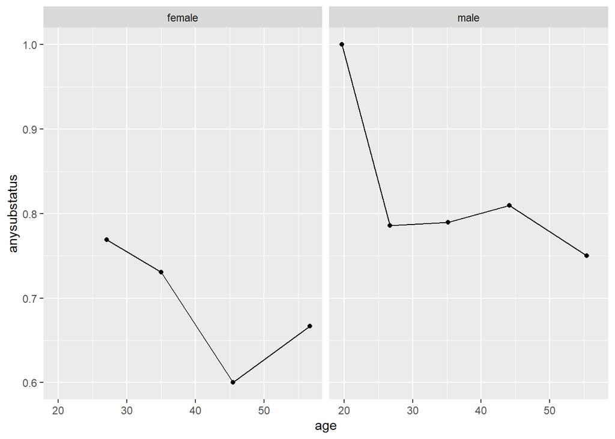

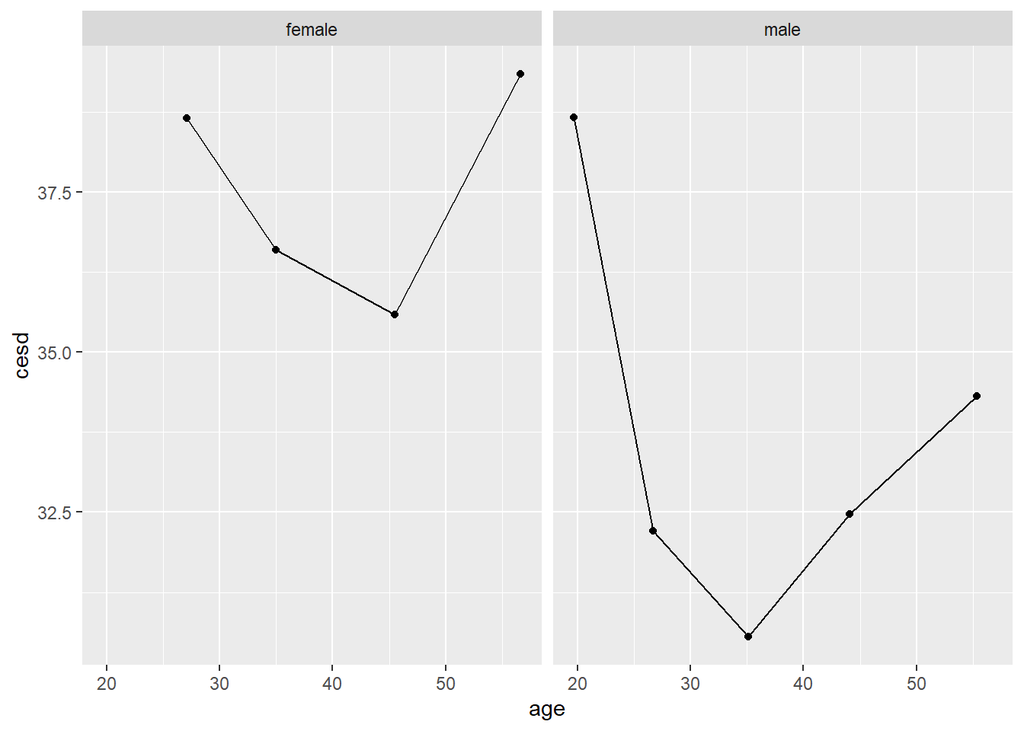

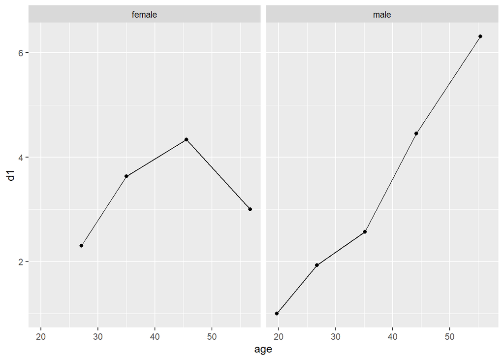

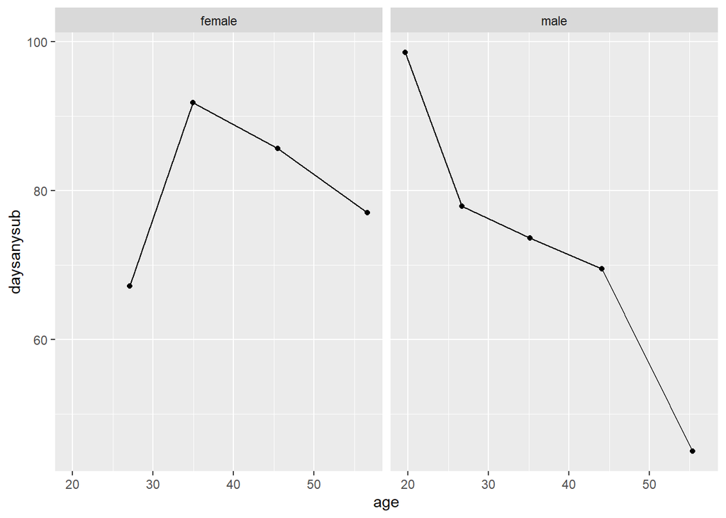

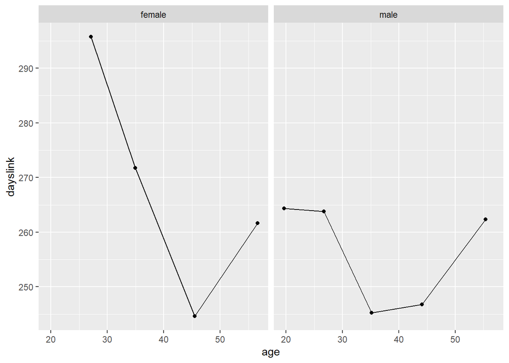

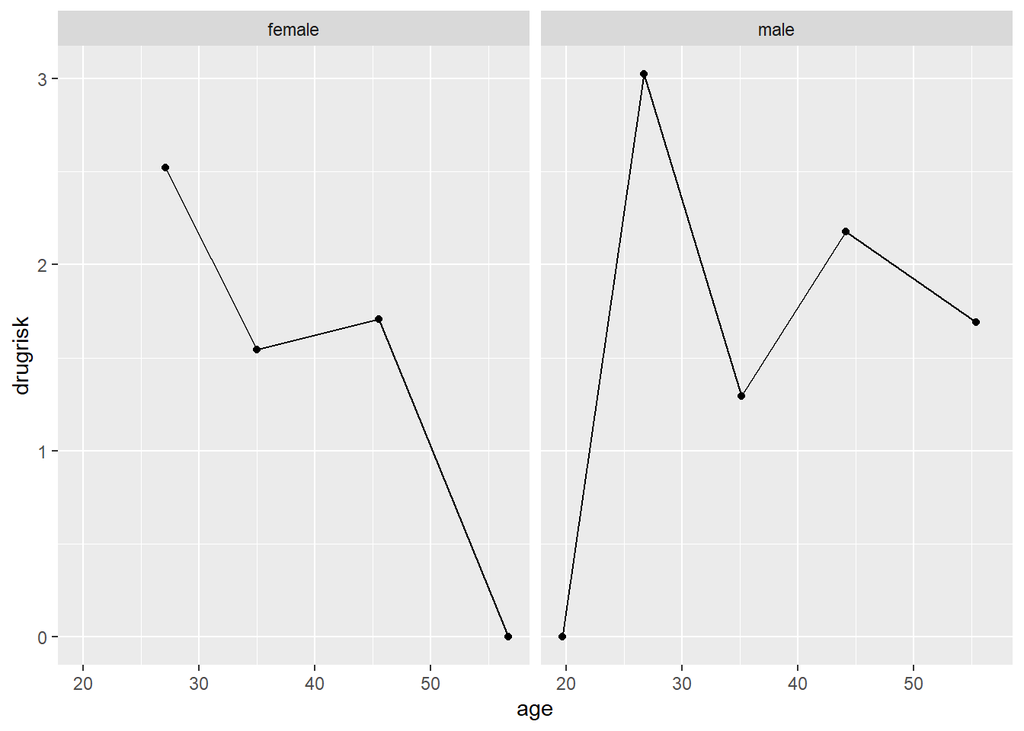

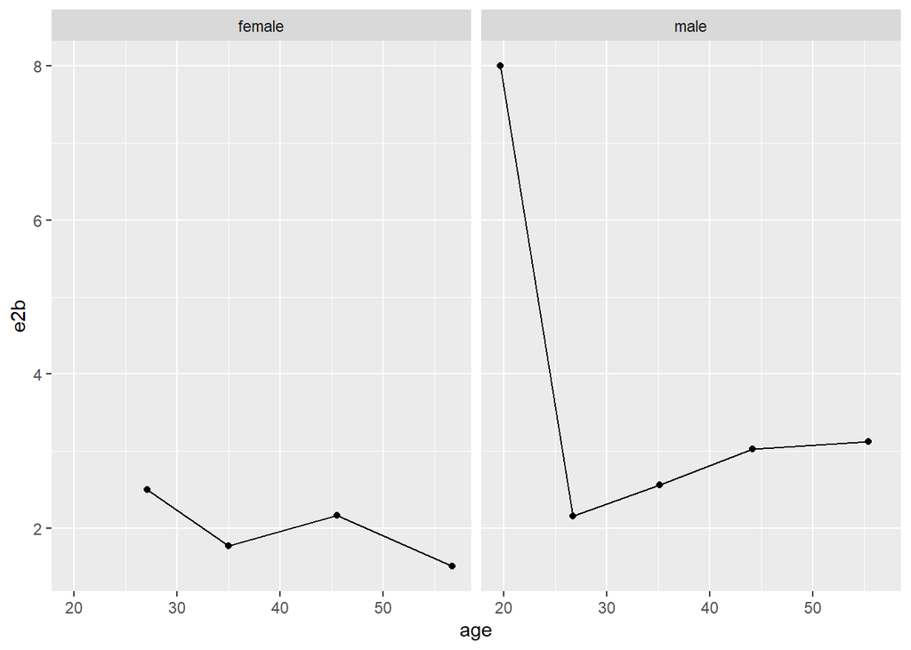

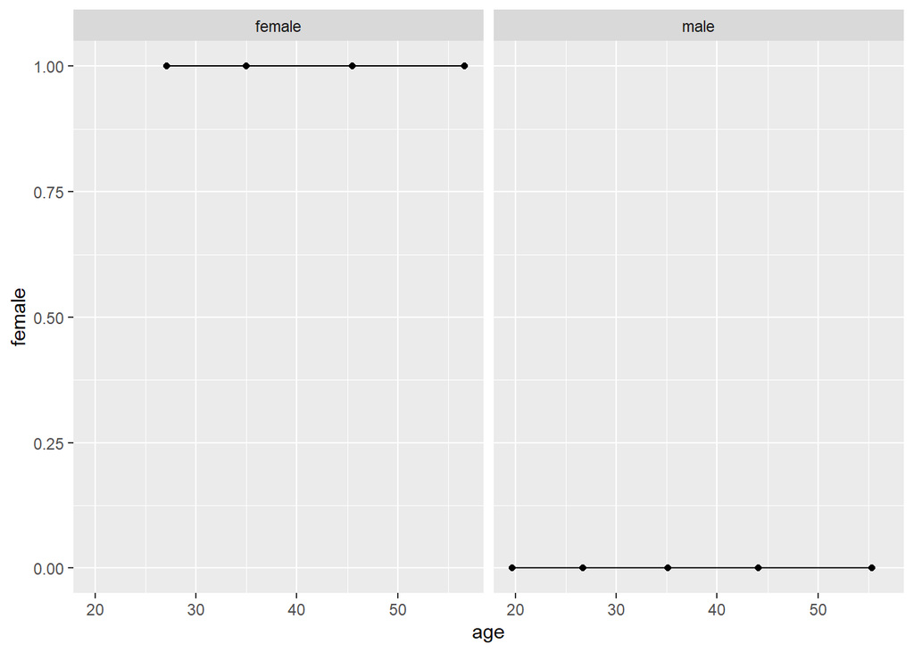

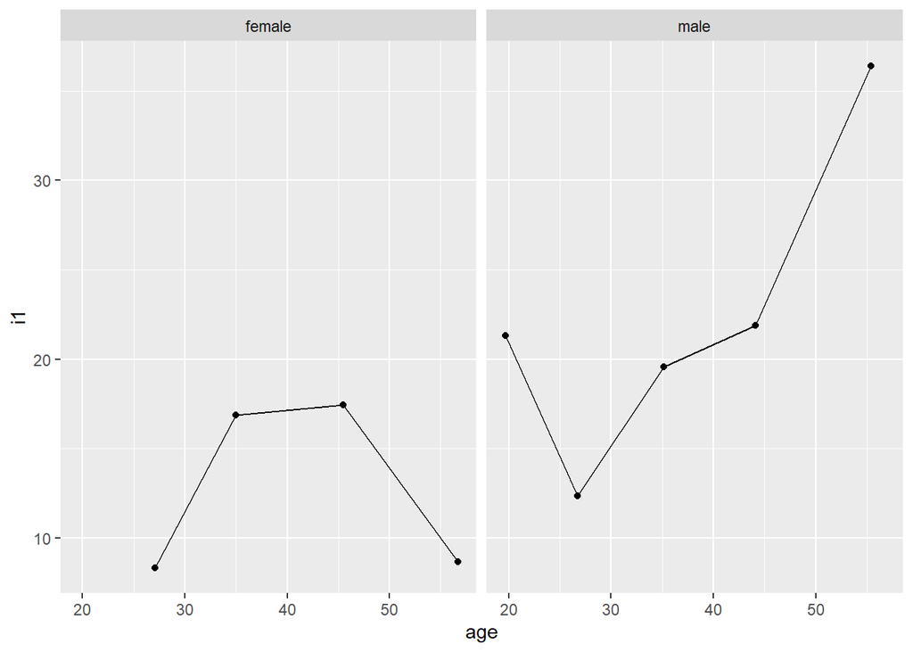

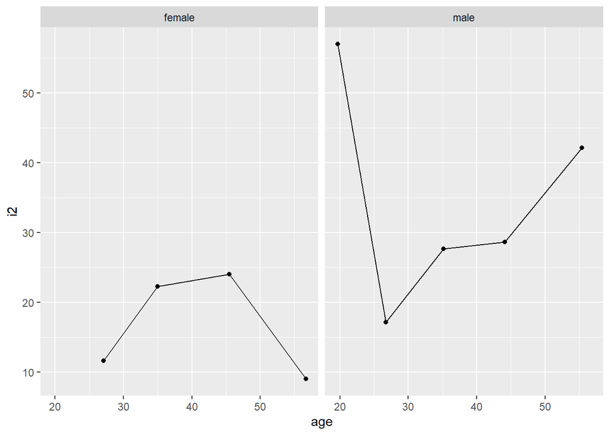

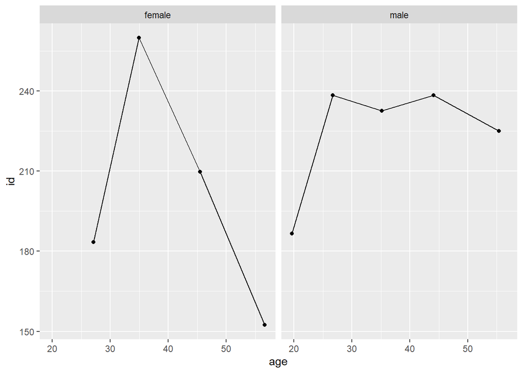

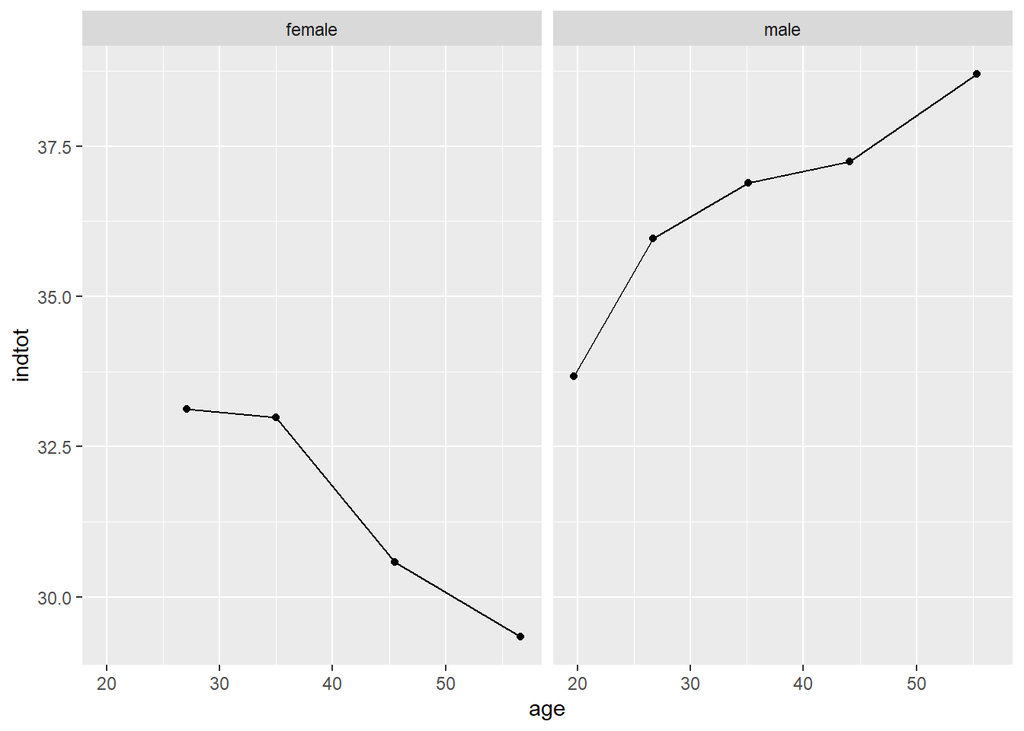

[8 more figures not shown]

```r
# correct answer!
HELPrct_agegroup %>% ungroup() %>%  select(where(is.numeric)&!age&!sex) %>% colnames() %>%  map(~ggplot(HELPrct_agegroup,aes(x=age,y=.data[[.]],group=1))+geom_line()+geom_point()+facet_wrap(~sex))
```

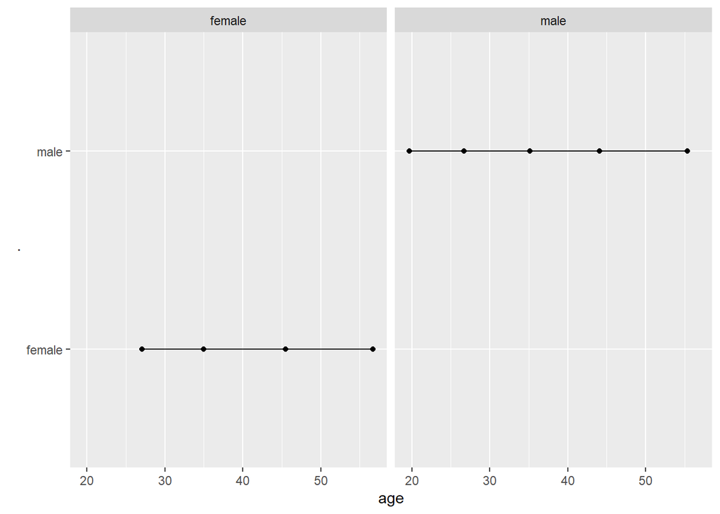

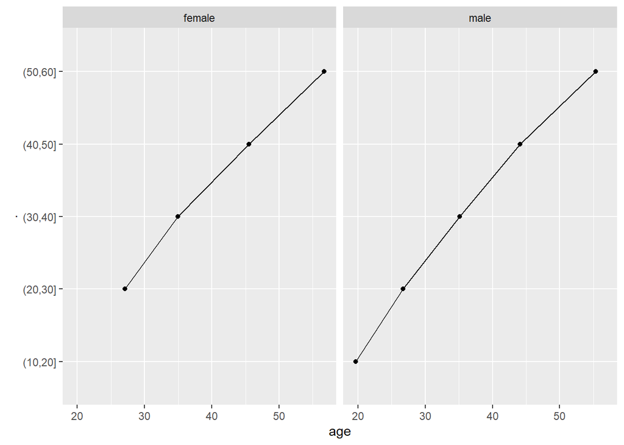

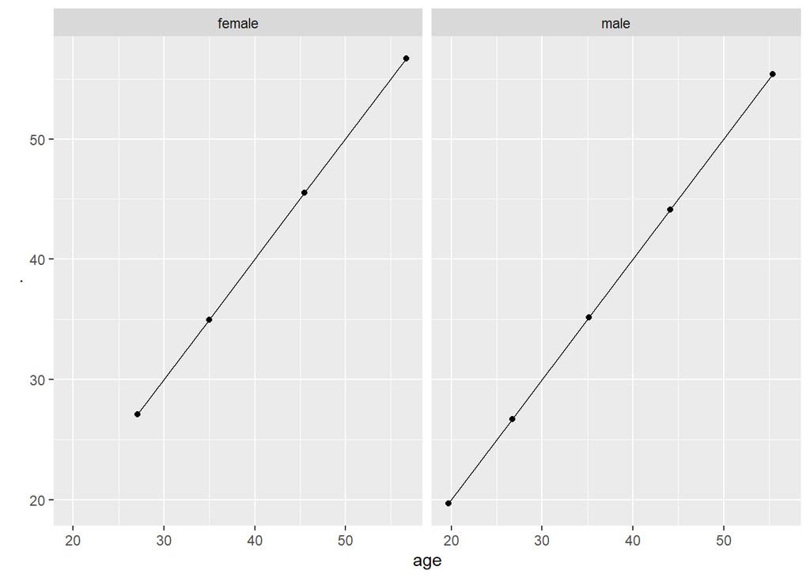

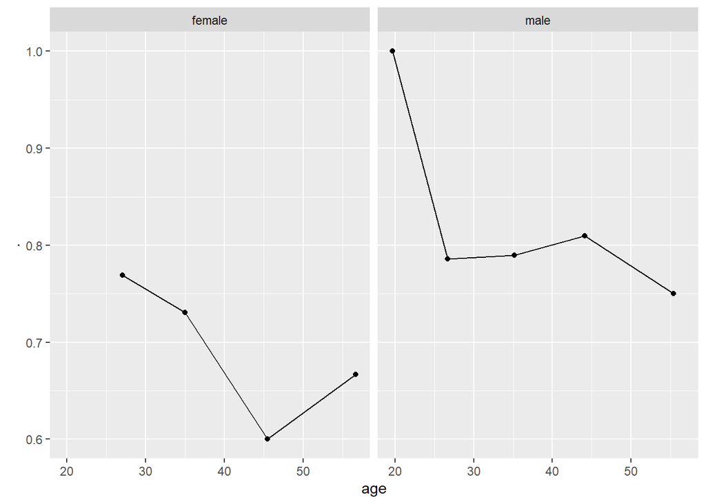

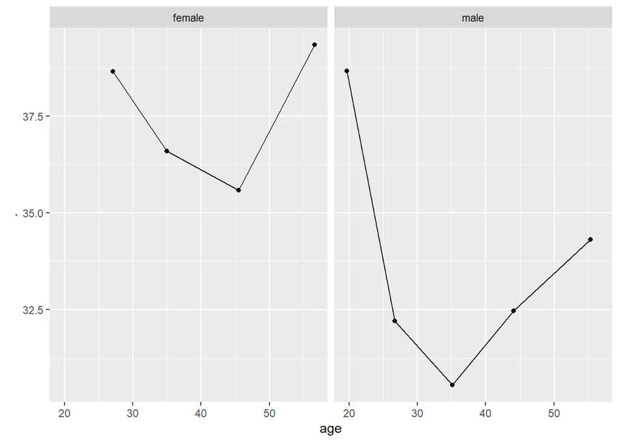

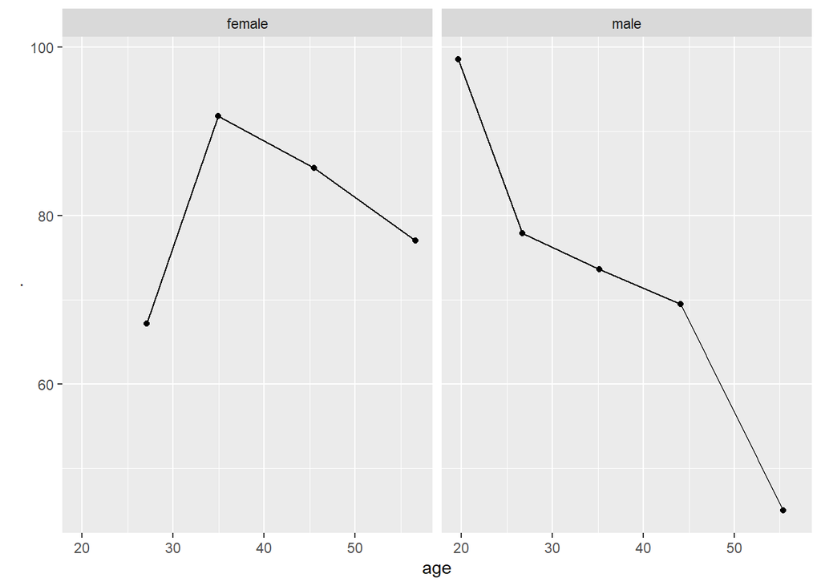

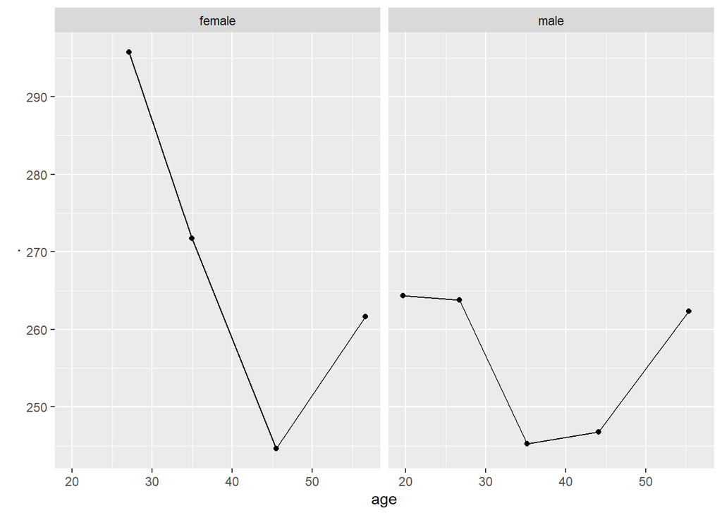

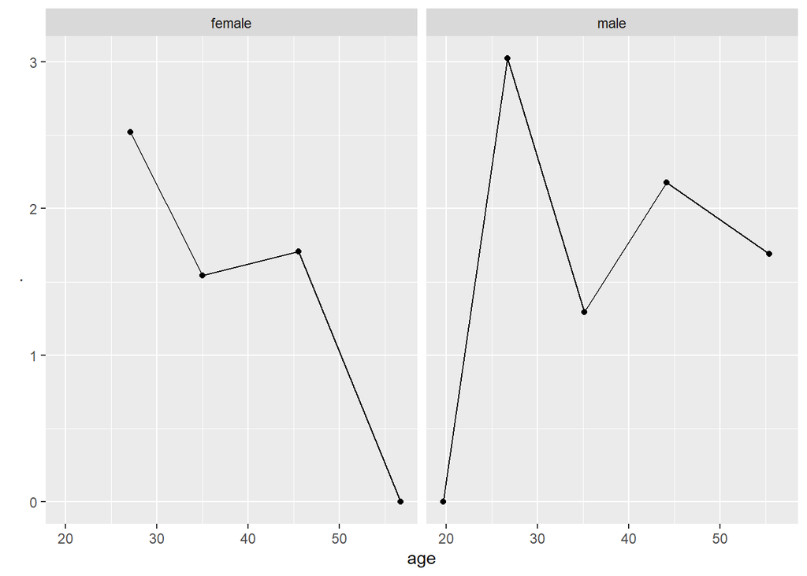

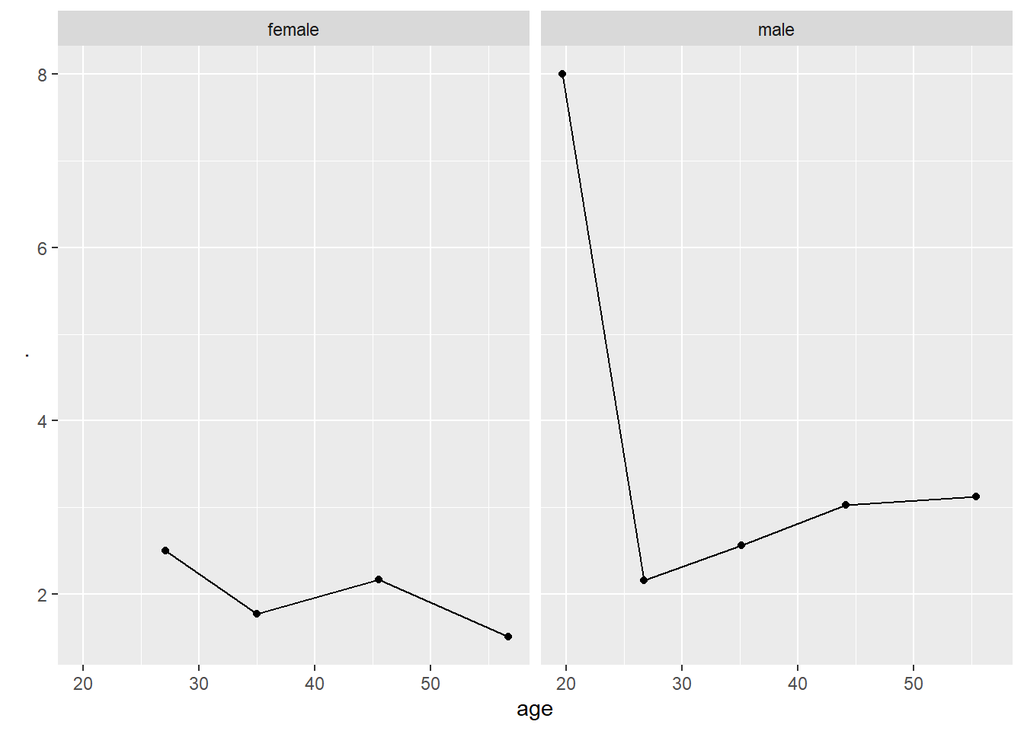

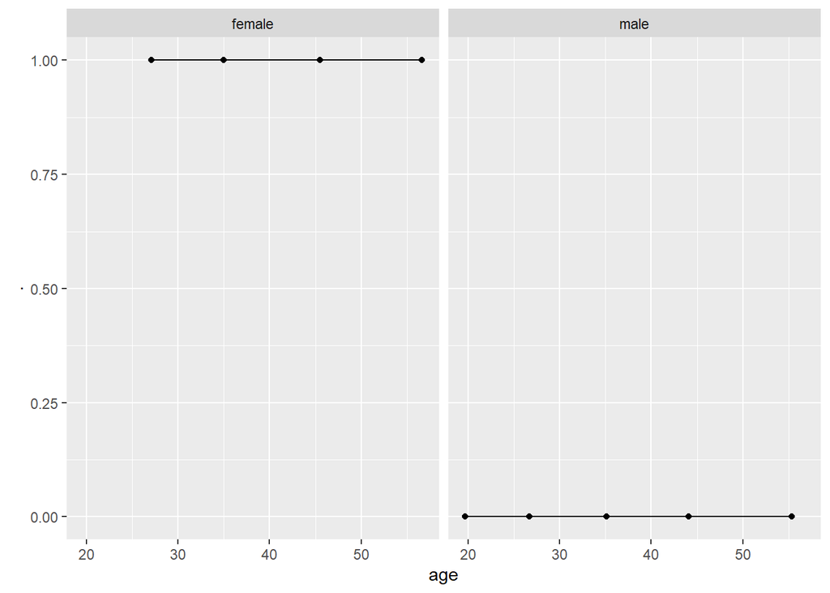

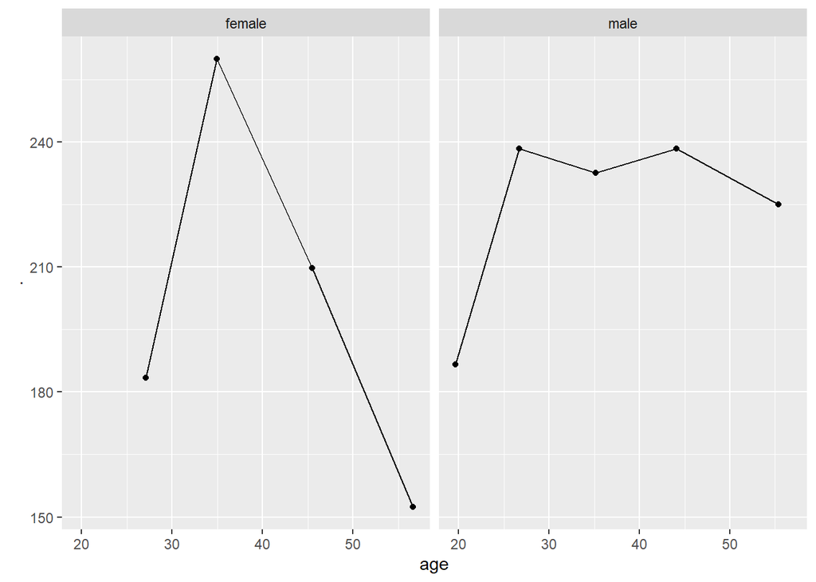

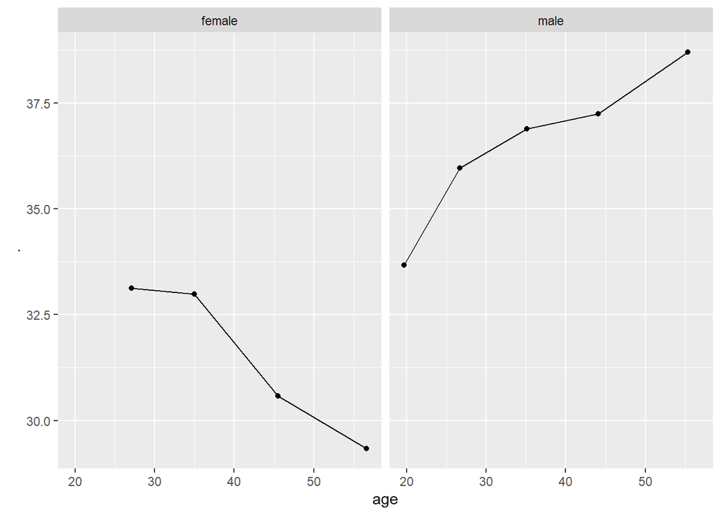

[5 more figures not shown]

```r
#kind of working but lack of label of Y
HELPrct_agegroup %>% map(~ggplot(HELPrct_agegroup,aes(x=age,y=.,group=1))+geom_line()+geom_point()+facet_wrap(~sex))
```

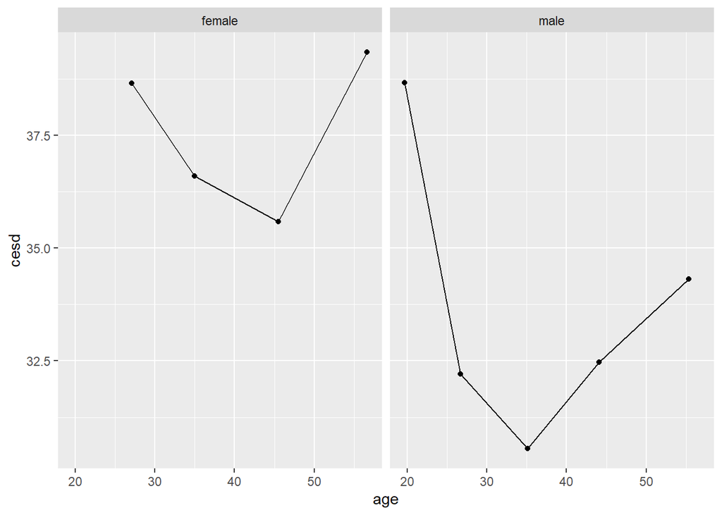

```r
#Another method, but not great, without Y label
# first generate a function of ggplot.
scatter_plot2 <- function(data, x, y) {
  ggplot(data, aes({{x}}, {{y}})) + geom_line() + geom_point() + facet_wrap(~sex)
}
scatter_plot2 (HELPrct_agegroup,age,cesd)
```